# Detección de Deforestación con Machine Learning

Infrraestructura en la nube para la de Clasificación Bosque/No-Bosque usando imagenes satelitales

Manuela Ramos Ospina y Juan Manuel Orozco Yepes

[figure not shown]

**Detección de Deforestación con Machine Learning**

Pipeline de Clasificación Bosque/No-Bosque usando Sentinel-2 y AWS

**Equipo de Minería de Datos**  
12 de noviembre de 2025

## 🌍 Contexto y Problemática

**La Deforestación en Colombia**

- 🌳 La **deforestación** responde principalmente a la **expansión agrícola** (legal e ilegal)
- 🪓 Actividades intensivas de **aprovechamiento forestal** comercial y doméstico
- 🗺️ Debido al carácter **altamente diverso** del país, cada región presenta condiciones biofísicas diferentes
- 🎯 El estudio a **escala subnacional** es clave para diagnósticos precisos y acciones focalizadas

## 🛰️ Herramientas Tecnológicas

- **Imágenes satelitales** + **SIG**: insumos fundamentales para mapeo y análisis espacial
- **Sentinel-2**: sensor crítico para delimitar áreas forestales de forma reproducible
- **Machine Learning**: identificación de coberturas, modelación de distribución de especies
- **AWS (S3, EC2, EMR)**: infraestructura cloud para procesamiento distribuido

**Ventaja Competitiva**

Pipeline **completamente reproducible** y **escalable**

## 🎯 Pregunta de Investigación

¿Cómo identificar automáticamente coberturas boscosas usando imágenes satelitales multiespectrales, mediante arquitecturas de big data y aprendizaje automático?

## 📊 Objetivo General

Desarrollar una infraestructura de big data para detectar bosque a partir de imágenes satelitales, empleando procesamiento distribuido y aprendizaje automático

## 🎯 Objetivos Específicos

1. **Implementar un pipeline de ingesta eficiente** de datos satelitales multiespectrales en zonas rurales
2. **Generar un conjunto de grandes volúmenes de datos** limpios de artefactos con características relevantes
3. **Diseñar modelos de aprendizaje automático** capaces de detectar bosque / no-bosque
4. **Optimizar el entrenamiento y validación** de los modelos para grandes volúmenes de datos

## 📦 Dataset y Características

### 📊 Shapes de fincas

- **distribuidas** en todo el país
- **Cantidad**: 20 fincas

## 🔄 Pipeline Completo de Procesamiento

**Paso 0: Ingesta de Datos** - Carga de shapefiles a S3 (perímetros y cobertura boscosa) - Descarga de imágenes Sentinel-2 históricas (productos .SAFE)

**Paso 1: Procesamiento Sentinel-2** (`01_procesar_sentinel_clip.py`) - Extracción de 10 bandas espectrales, remuestreo (10m), reproyección (EPSG:4326), recorte al perímetro

**Paso 2: Tabulación de Features** (`03_tabular_features.py`) - Extracción pixel-a-pixel, composición temporal (mediana, p25, p75), conteo de observaciones

**Paso 3: Rasterización de Labels** (`04_rasterizar_labels.py`) - Reproyección de shapefiles, rasterización de bosque, erosión morfológica de bordes

**Paso 4: Unión Features + Labels** (`05_unir_features_labels.py`) - Combina features espectrales con labels, filtrado de píxeles válidos

**Paso 5: Consolidación Multi-Zona** (`process_all_zones_pipeline.py`) - Descubrimiento automático, validación, concatenación, generación de reporte

## 📊 Estadísticas y Calidad del Dataset

### 📈 Distribución

- **Total**: 8,008 píxeles
- **Bosque (1)**: 1,820 (22.7%)
- **No-Bosque (0)**: 6,188 (77.3%)
- **Features**: 15 variables espectrales
- **Formato**: Parquet (eficiente)

### ✅ Fortalezas

- Cantidad suficiente para ML
- Diversidad geográfica (4 departamentos)
- Labels validados con shapefiles
- Erosión de bordes aplicada

### ⚠️ Consideraciones

- **Desbalance moderado** (3.4:1)
  - Requiere balanceo en entrenamiento
  - `class_weight='balanced'` implementado
- **Zona 79 problemática** (749:1)
  - Casi sin bosque
  - Considerar exclusión
- **Variabilidad temporal limitada**
  - Composite anual
  - No series temporales completas

## ☁️ Infraestructura AWS

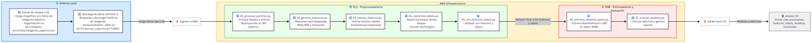

## 🤖 Entrenamiento del Modelo

**Algoritmo**: Random Forest Classifier

**Configuración**

```python
RandomForestClassifier(
  n_estimators=100,
  max_depth=10,
  min_samples_split=10,
  min_samples_leaf=5,
  class_weight='balanced',
  random_state=42
)
```

**División de Datos** - **Train**: 70% (5,608 muestras) - **Validation**: 15% (1,198) - **Test**: 15% (1,202)

**Distribución de Clases** - No-Bosque: 77.3% - Bosque: 22.7%

## 📊 Resultados Principales

### 🎯 Métricas en Test Set

| Métrica | Valor | Interpretación |
| --- | --- | --- |
| **Accuracy** | **90.35%** | Tasa de acierto general |
| **Precision** | 72.89% | 73 de cada 100 predicciones correctas |
| **Recall** | **91.58%** | Detecta 9 de cada 10 áreas boscosas |
| **F1-Score** | 81.17% | Balance precision-recall |
| **ROC AUC** | **96.16%** | Excelente discriminación |
| **PR AUC** | **85.42%** | Muy bueno para clases desbalanceadas |

## 🎯 Matriz de Confusión

|  | Pred: No-Bosque | Pred: Bosque |
| --- | --- | --- |
| **Real: No-Bosque** | **836** ✅ | 93 ❌ |
| **Real: Bosque** | 23 ❌ | **250** ✅ |

### Interpretación

- **TN**: 836 (90.0%) - Correctos no-bosque
- **FP**: 93 (10.0%) - Falsos positivos
- **FN**: 23 (8.4%) - Bosque no detectado
- **TP**: 250 (91.6%) - Correctos bosque

**Tasa de Error**

**Falsos Negativos**: 8.42%

El modelo pierde algunas áreas de bosque, pero la tasa es aceptable.

## 📊 Análisis de Features

### 🔝 Top 5 Features

| Rank | Feature | Importancia |
| --- | --- | --- |
| 🥇 | `B03_med` (Verde) | **18.90%** |
| 🥈 | `NDVI_range` | **11.67%** |
| 🥉 | `B11_med` (SWIR) | **9.99%** |
| 4 | `B05_med` (Red Edge) | 9.31% |
| 5 | `n_obs` | 8.94% |

**Total bandas espectrales**: 61.86%

### 📈 Insights

**Bandas Espectrales Clave** - Verde (B03): Reflectancia vegetación - SWIR (B11, B12): Contenido humedad - Red Edge (B05): Estado vegetación

**Variabilidad Temporal** - NDVI_range: Cambios estacionales - n_obs: Calidad temporal - Percentiles: Extremos condiciones

La **dinámica temporal** es crucial para discriminación

## ✅ Fortalezas y ⚠️ Áreas de Mejora

### ✅ Fortalezas

1. **Alto Recall (91.58%)**
   - Detecta mayoría de bosques
   - Bajo riesgo de pérdida
2. **Excelente ROC AUC (96.16%)**
   - Muy buena discriminación
3. **Features Interpretables**
   - Bandas espectrales conocidas
   - NDVI validado científicamente

### ⚠️ Áreas de Mejora

**1. Precision (72.89%)** - ~27% falsos positivos - Soluciones: más datos, ajuste umbrales, features adicionales

**2. Desbalance de Clases** - Estrategia: `class_weight='balanced'` - Alternativas: SMOTE, undersampling

**3. Validación Geográfica** - Split por zonas (no aleatorio) - Evaluar generalización espacial

## 🎓 Conclusiones

✅ **Pipeline completo y funcional** implementado exitosamente

✅ **Modelo con 90.35% de accuracy** en detección de cobertura forestal

✅ **Infraestructura escalable** en AWS (S3, EC2, EMR)

✅ **Flujo reproducible** con scripts documentados

✅ **Features interpretables** basadas en evidencia científica

✅ **Dataset de calidad** con 8,008 muestras validadas

## 🌟 Impacto y Aplicaciones

### 🌍 Aplicaciones Ambientales

- Monitoreo de deforestación
- Conservación de biodiversidad
- Cumplimiento normativo
- Reportes de carbono
- Gestión de riesgos ambientales

### 💼 Valor Comercial

- Due diligence ambiental
- Certificación forestal
- Evaluación de riesgos
- Planificación territorial
- Toma de decisiones informada

## 📚 Referencias y Documentación

### 📖 Documentación del Proyecto

- `README.md` - Guía general y resultados principales
- `DATA_PREP.md` - Preparación detallada de datos
- `RESULTADOS_ENTRENAMIENTO.md` - Análisis completo de métricas
- `EMR_TRAINING.md` - Entrenamiento distribuido en Spark
- `config/*.yaml` - Configuración de parámetros

### 🔗 Recursos Externos

- [Sentinel-2 Documentation](https://sentinel.esa.int/web/sentinel/missions/sentinel-2)
- [AWS EMR Spark](https://aws.amazon.com/emr/)
- [Scikit-learn Random Forest](https://scikit-learn.org/stable/)

### 🗂️ Repositorio

- GitHub: `github.com/maraosoc/mineria_project`

## 🙏 ¡Gracias!

### Preguntas y Discusión

**Equipo de Minería de Datos**

📊 Proyecto: Detección de Deforestación con ML

🛰️ Tecnologías: Sentinel-2 · AWS · Spark · Python